# Exploratory Data Analysis of 100K MovieLens Data

##### Previous articles

- MovieLens Project Part 2

This is the first post of a project on the [MovieLens](https://grouplens.org/datasets/movielens/) dataset to learn about collaborative filtering algorithms. Here, I do an exploratory data analysis to see what the data looks like. The remainder of this post is straight out of a Jupyter Notebook file you can download here. You can also see it [here](https://github.com/benlindsay/movielens-analysis/blob/master/01_Exploratory-Analysis-on-100K-data.ipynb) on GitHub.

I have most of the code collapsed in the boxes that say "Expand Code" so we can skip right to the visualizations, but all of the code is here if you expand the code blocks. Thanks to [Jake Vanderplas](http://vanderplas.com/) for the amazing [Pelican plugin](https://github.com/getpelican/pelican-plugins/tree/master/liquid_tags) that makes this possible.

As part of a project sponsored by the data science team at [Air Liquide](https://www.airliquide.com/) here in Philadelphia, I'm diving deep into collaborative filtering algorithms. There are 2 main goals of this project:

1. Gain understanding of a variety of collaborative filtering algorithms by implementing them myself
2. Compare quality and speed of a variety of algorithms as a function of dataset size

The data I'm using comes from the [GroupLens](https://grouplens.org/) research group, who has been collecting movie ratings from volunteers since 1995 and has curated datasets of a variety of sizes. For the initial development phase of the project, I'll focus on the 100K dataset, the smallest one, to enable faster iteration. I'll scale up to larger datasets later on.

Before getting into any algorithm development, I want to get a picture of the data I'm working with, so I'll ask the questions on my mind and try to answer them with the data.

## Get the data

```python
!mkdir -p raw
!curl -O http://files.grouplens.org/datasets/movielens/ml-100k.zip
!unzip -o ml-100k.zip -d raw/
!rm ml-100k.zip
```

```
  % Total    % Received % Xferd  Average Speed   Time    Time     Time  Current
                                 Dload  Upload   Total   Spent    Left  Speed
100 4808k  100 4808k    0     0  1783k      0  0:00:02  0:00:02 --:--:-- 1783k
Archive:  ml-100k.zip
  inflating: raw/ml-100k/allbut.pl
  inflating: raw/ml-100k/mku.sh
  inflating: raw/ml-100k/README
  inflating: raw/ml-100k/u.data
  inflating: raw/ml-100k/u.genre
  inflating: raw/ml-100k/u.info
  inflating: raw/ml-100k/u.item
  inflating: raw/ml-100k/u.occupation
  inflating: raw/ml-100k/u.user
  inflating: raw/ml-100k/u1.base
  inflating: raw/ml-100k/u1.test
  inflating: raw/ml-100k/u2.base
  inflating: raw/ml-100k/u2.test
  inflating: raw/ml-100k/u3.base
  inflating: raw/ml-100k/u3.test
  inflating: raw/ml-100k/u4.base
  inflating: raw/ml-100k/u4.test
  inflating: raw/ml-100k/u5.base
  inflating: raw/ml-100k/u5.test
  inflating: raw/ml-100k/ua.base
  inflating: raw/ml-100k/ua.test
  inflating: raw/ml-100k/ub.base
  inflating: raw/ml-100k/ub.test
```

Expand Code

Let's load and examine the ratings data. I sort the data by `timestamp` and break the `timestamp` column out into `year` and `month` and display the first 5 and last 5 ratings in the dataset.

Expand Code

```
First 5:
```

|  | userId | movieId | rating | timestamp | year | month |
| --- | --- | --- | --- | --- | --- | --- |
| 214 | 259 | 255 | 4 | 1997-09-19 23:05:10 | 1997 | 9 |
| 83965 | 259 | 286 | 4 | 1997-09-19 23:05:27 | 1997 | 9 |
| 43027 | 259 | 298 | 4 | 1997-09-19 23:05:54 | 1997 | 9 |
| 21396 | 259 | 185 | 4 | 1997-09-19 23:06:21 | 1997 | 9 |
| 82655 | 259 | 173 | 4 | 1997-09-19 23:07:23 | 1997 | 9 |

```
Last 5:
```

|  | userId | movieId | rating | timestamp | year | month |
| --- | --- | --- | --- | --- | --- | --- |
| 46773 | 729 | 689 | 4 | 1998-04-22 19:10:38 | 1998 | 4 |
| 73008 | 729 | 313 | 3 | 1998-04-22 19:10:38 | 1998 | 4 |
| 46574 | 729 | 328 | 3 | 1998-04-22 19:10:38 | 1998 | 4 |
| 64312 | 729 | 748 | 4 | 1998-04-22 19:10:38 | 1998 | 4 |
| 79208 | 729 | 272 | 4 | 1998-04-22 19:10:38 | 1998 | 4 |

We can see from these rows that this part of the dataset is user-movie-rating triplets at different points in time. Let's ask some questions about the data to get a feel for what we're working with:

# 1. How are the ratings distributed?

I'd like to see what ratings are common and uncommon, so let's just plot counts of each rating:

Expand Code

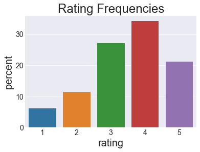

# 2. How many ratings were submitted per month?

Expand Code

| Date | year | month | # of Ratings |
| --- | --- | --- | --- |
| 1997-09-01 | 1997 | 9 | 6808 |
| 1997-10-01 | 1997 | 10 | 10368 |
| 1997-11-01 | 1997 | 11 | 24073 |
| 1997-12-01 | 1997 | 12 | 11695 |
| 1998-01-01 | 1998 | 1 | 14100 |
| 1998-02-01 | 1998 | 2 | 10961 |
| 1998-03-01 | 1998 | 3 | 12987 |
| 1998-04-01 | 1998 | 4 | 9008 |

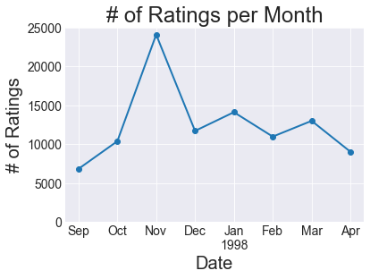

This leads to another question about changes over time:

# 5. How consistent are the average ratings over time?

Expand Code

| Date | year | month | Rating | std |
| --- | --- | --- | --- | --- |
| 1997-09-01 | 1997 | 9 | 3.541569 | 1.091807 |
| 1997-10-01 | 1997 | 10 | 3.594425 | 1.097959 |
| 1997-11-01 | 1997 | 11 | 3.558759 | 1.110674 |
| 1997-12-01 | 1997 | 12 | 3.578367 | 1.110067 |
| 1998-01-01 | 1998 | 1 | 3.397092 | 1.187497 |
| 1998-02-01 | 1998 | 2 | 3.456619 | 1.128093 |
| 1998-03-01 | 1998 | 3 | 3.548395 | 1.109802 |
| 1998-04-01 | 1998 | 4 | 3.576710 | 1.142116 |

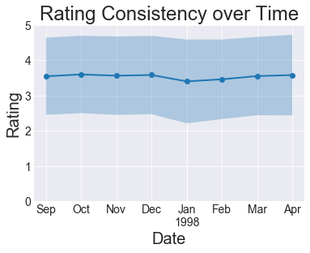

This average ratings were fairly consistent around 3.5. The lack of large changes over time will simplify modeling a little bit.

One last thing I'm curious about (for now) when it comes to changes over time:

# 6. How quickly do the movie and user bases grow over time?

I'll assume that a user has joined on her first rating, and that she remains a user from then on.

Expand Code

|  | userId | movieId | rating | timestamp | year | month | Date |
| --- | --- | --- | --- | --- | --- | --- | --- |
| 214 | 259 | 255 | 4 | 1997-09-19 23:05:10 | 1997 | 9 | 1997-09-01 |
| 83965 | 259 | 286 | 4 | 1997-09-19 23:05:27 | 1997 | 9 | 1997-09-01 |
| 43027 | 259 | 298 | 4 | 1997-09-19 23:05:54 | 1997 | 9 | 1997-09-01 |
| 21396 | 259 | 185 | 4 | 1997-09-19 23:06:21 | 1997 | 9 | 1997-09-01 |
| 82655 | 259 | 173 | 4 | 1997-09-19 23:07:23 | 1997 | 9 | 1997-09-01 |

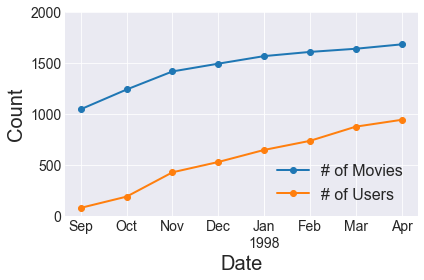

New users seen in the dataset look fairly linear over time, although the number of movies start out withover 1000 already in the system.

# 7. How sparse is the user/movies matrix we'll be dealing with?

Here's one way to visualize the sparsity. The plot below shows a single, tiny black square for every user/movie combination we have. If everyone rated every movie, you'd see a solid black rectangle. Instead what we see is a lot of white--lots of user/movie combinations for which we don't have a rating (yet). You especially see a lot of white in the top right corner. This is probably because early raters had access to fewer movies to rate, and new users progressively had more movies to rate as they were added to the system.

Expand Code

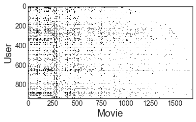

The matrix density is $n_{ratings}/(n_{users} \times n_{movies}) = 0.063$

In the plot above you also notice that there are a few darker rows and columns, but most rows and columns are pretty bare. Let's visualize the distributions of number of ratings by user and by movie. The way I chose to visualize this is with an [Empirical Cumulative Distribution Function (ECDF) plot](https://www.youtube.com/watch?v=ap4mfGvgDsM). An ECDF plot has an advantage compared to a histogram that all data points can be plotted in a meaningful way, and no bin size has to be chosen to average arbitrary chunks of it. This is especially helpful with the long-tailed distributions here.

Expand Code

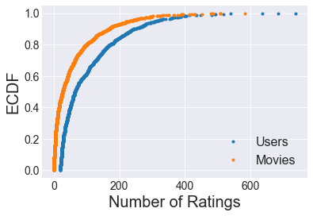

In the plot above, you can learn, for example, that 40% of all users rated 50 or less movies, and 90% of movies have 169 or less ratings. In general, we seen that a large fraction of movies and users have few ratings associated with them, but a few movies and users have many more ratings.

The main thing to take from this though is that the matrix of possible ratings is quite sparse, and that we need to use models that deal with this lack of data.

##### Previous articles

- MovieLens Project Part 2

## Comments

[comments powered by Disqus](http://disqus.com)